# Per-cohort analysis and cross-cohort transfer

Deep immune cell phenotyping predicts influenza vaccine immunogenicity in HCT recipients

July 21, 2026

# 1 What this notebook does

The two trials enrolled different populations (pediatric versus adult) at different transplant centers, so pooling them requires the cellular signature to behave consistently across cohorts. This notebook examines that in three ways and adds a transfer diagnostic. It produces:

- **Figure 5** – per-cohort predictive gain, per-cohort feature selection, and per-cohort baseline-titer stratification.
- **Supplementary Figure (cross-cohort transfer)** – what happens when a model trained on one cohort is applied to the other.

The four-model ladder is refit independently within each cohort, using the same production atlas, the same recipient-grouped nested cross-validation, and the same recipient-clustered bootstrap as the pooled analysis.

```r
# Edit these to your local copy of the intermediate data (not distributed; see
# README, Data Availability).
FAST <- "/fast/datasets/flu_cellular_prediction"
REPO <- "/home/amir/repo/flu-cellular-prediction"

PC_DIR    <- file.path(FAST, "post_hoc_5000", "per_cohort")
PC_RDATA  <- file.path(PC_DIR, "E5_per_cohort.RData")
BOOT_PATH <- file.path(FAST, "post_hoc_5000", "recipient_bootstrap", "E3_recipient_boot.RData")
ATLAS_FILE <- file.path(REPO, "results", "final_atlas_production", "final_atlas_e862228d.RData")
ANN_FILE  <- file.path(REPO, "results", "reports", "cluster_annotations_corrected.csv")
```

```r
if (file.exists(PC_RDATA)) {
  # Load the per-cohort refit results (fast; the nested CV was already run).
  pc <- new.env(parent = emptyenv()); load(PC_RDATA, envir = pc)
  per_cohort_summary <- fread(file.path(PC_DIR, "E5_summary.csv"))   # peds/adult gains
  sel_summary <- as.data.table(pc$sel_summary)                       # feature selection
  strat_all   <- as.data.table(pc$strat_all)                         # per-cohort quartiles
} else {
  # ---- Heavy compute: refit the four-model ladder within each cohort with
  #      recipient-grouped nested CV and recipient-clustered bootstrap. This
  #      needs the raw CyTOF object and the atlas helpers (available from the
  #      corresponding author); it is the per-cohort analog of notebooks 01-02. ----
  stop("Per-cohort refit results not found. Rebuild with the per-cohort ",
       "pipeline (needs raw data + helpers).")
}

# Pooled reference values come from the recipient-clustered bootstrap (Table 2),
# so Figure 5A shows the pooled estimate on the same footing as the per-cohort ones.
boot <- new.env(parent = emptyenv()); load(BOOT_PATH, envir = boot)
pool <- as.data.frame(boot$results_df)
pool <- pool[pool$scope == "overall" & pool$comparison %in% c("M1_to_M3", "M2_to_M4"), ]
pooled <- data.table(cohort = "pooled", comparison = pool$comparison,
                     delta_pct = pool$delta_pct, ci_low = pool$ci_low_pct,
                     ci_high = pool$ci_high_pct, p_two_sided = pool$p_two_sided)

ann <- as.data.table(read.csv(ANN_FILE, stringsAsFactors = FALSE))
ann[, cluster_id := as.integer(cluster_id)]
ann[, short := trimws(gsub("\\s+", " ", gsub("\\s*\\(.*?\\)", "", annotation)))]
```

# 2 Figure 5

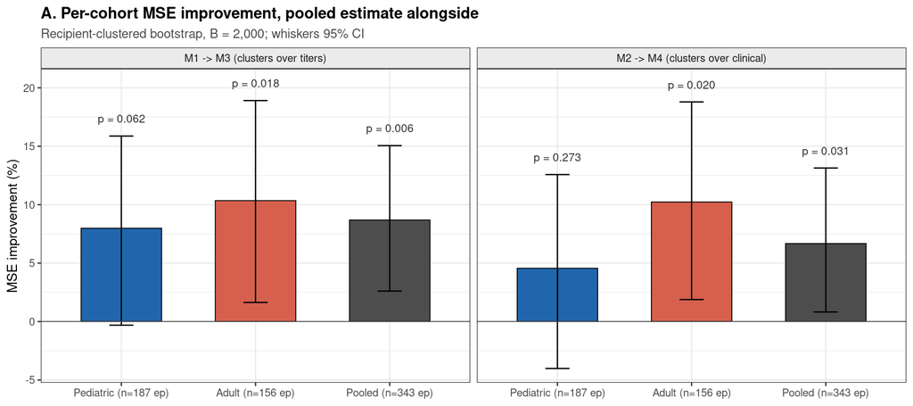

```r
# --- Panel A: per-cohort MSE improvement with the pooled estimate alongside ---
summary_all <- rbind(per_cohort_summary, pooled, fill = TRUE)
summary_all[, cohort := factor(cohort, levels = c("peds", "adult", "pooled"),
  labels = c("Pediatric (n=187 ep)", "Adult (n=156 ep)", "Pooled (n=343 ep)"))]
summary_all[, comparison := factor(comparison, levels = c("M1_to_M3", "M2_to_M4"),
  labels = c("M1 -> M3 (clusters over titers)", "M2 -> M4 (clusters over clinical)"))]

cohort_colors <- c("Pediatric (n=187 ep)" = "#2166ac",
                   "Adult (n=156 ep)" = "#d6604d", "Pooled (n=343 ep)" = "#4d4d4d")
p_a <- ggplot(summary_all, aes(cohort, delta_pct, fill = cohort)) +
  geom_col(width = 0.6, color = "black", linewidth = 0.3) +
  geom_errorbar(aes(ymin = ci_low, ymax = ci_high), width = 0.18) +
  geom_hline(yintercept = 0, color = "gray30", linewidth = 0.3) +
  geom_text(aes(label = sprintf("p = %.3f", p_two_sided), y = ci_high + 1.5),
            size = 2.8, color = "gray20") +
  facet_wrap(~ comparison, nrow = 1) +
  scale_fill_manual(values = cohort_colors, guide = "none") +
  labs(title = "A. Per-cohort MSE improvement, pooled estimate alongside",
       subtitle = "Recipient-clustered bootstrap, B = 2,000; whiskers 95% CI",
       x = NULL, y = "MSE improvement (%)") +
  theme_bw(base_size = 9.5) +
  theme(plot.title = element_text(face = "bold", size = 11),
        plot.subtitle = element_text(color = "gray30", size = 9),
        strip.background = element_rect(fill = "gray92"))
p_a
```

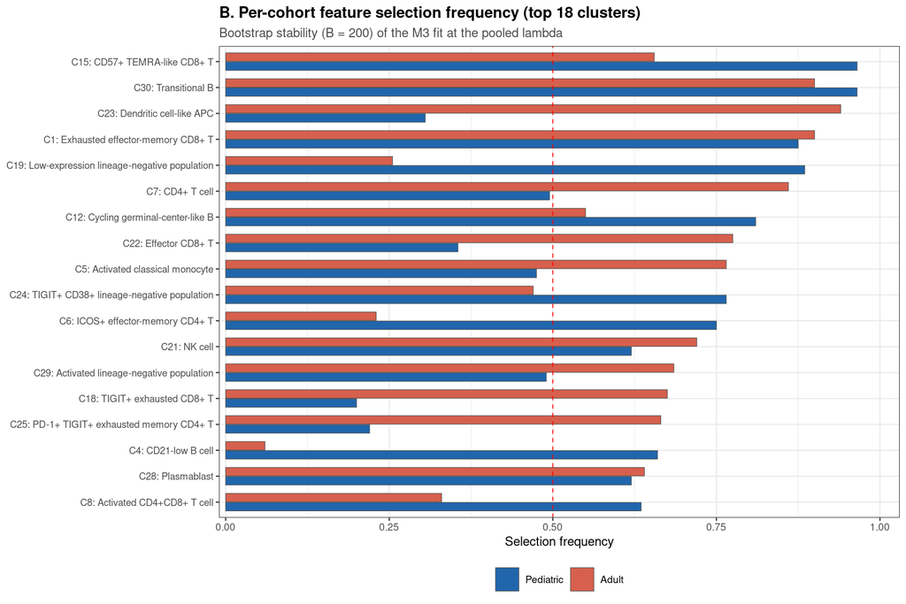

```r
# --- Panel B: per-cohort selection frequency of the top cluster features ---
# Drop the three baseline titers (selected in 100% of bootstraps in both cohorts).
sel <- sel_summary[!grepl("^baseline_", feature)]
sel[, cluster_id := as.integer(sub("cluster_", "", feature))]
short_lu <- setNames(ann$short, as.character(ann$cluster_id))
sel[, label := sprintf("C%d: %s", cluster_id, short_lu[as.character(cluster_id)])]
sel[, max_freq := pmax(peds_freq, adult_freq)]
setorder(sel, -max_freq)
top18 <- sel[1:18]

sel_long <- melt(top18[, .(label, peds_freq, adult_freq)], id.vars = "label",
                 variable.name = "cohort_var", value.name = "freq")
sel_long[, cohort := factor(cohort_var, levels = c("peds_freq", "adult_freq"),
                            labels = c("Pediatric", "Adult"))]
sel_long[, label := factor(label, levels = rev(top18$label))]

p_b <- ggplot(sel_long, aes(freq, label, fill = cohort)) +
  geom_col(position = position_dodge(width = 0.7), width = 0.65,
           color = "gray30", linewidth = 0.2) +
  geom_vline(xintercept = 0.5, color = "red", linetype = "dashed", linewidth = 0.3) +
  scale_fill_manual(values = c("Pediatric" = "#2166ac", "Adult" = "#d6604d"), name = NULL) +
  scale_x_continuous(limits = c(0, 1.02), expand = expansion(0.01)) +
  labs(title = "B. Per-cohort feature selection frequency (top 18 clusters)",
       subtitle = "Bootstrap stability (B = 200) of the M3 fit at the pooled lambda",
       x = "Selection frequency", y = NULL) +
  theme_bw(base_size = 9) +
  theme(plot.title = element_text(face = "bold", size = 11),
        plot.subtitle = element_text(color = "gray30", size = 9),
        legend.position = "bottom", axis.text.y = element_text(size = 7))
p_b
```

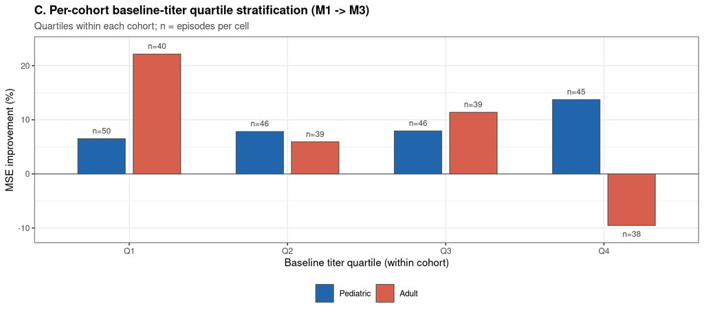

```r
# --- Panel C: per-cohort baseline-titer quartile stratification (M1 -> M3) ---
strat_all[, cohort_lbl := factor(cohort, levels = c("peds", "adult"),
                                 labels = c("Pediatric", "Adult"))]
p_c <- ggplot(strat_all, aes(quartile, improvement_pct, fill = cohort_lbl)) +
  geom_col(position = position_dodge(width = 0.7), width = 0.6,
           color = "gray30", linewidth = 0.3) +
  geom_hline(yintercept = 0, color = "gray30", linewidth = 0.3) +
  geom_text(aes(label = sprintf("n=%d", n),
                y = ifelse(improvement_pct >= 0, improvement_pct + 1.5, improvement_pct - 1.5)),
            position = position_dodge(width = 0.7), size = 2.6, color = "gray25") +
  scale_fill_manual(values = c("Pediatric" = "#2166ac", "Adult" = "#d6604d"), name = NULL) +
  labs(title = "C. Per-cohort baseline-titer quartile stratification (M1 -> M3)",
       subtitle = "Quartiles within each cohort; n = episodes per cell",
       x = "Baseline titer quartile (within cohort)", y = "MSE improvement (%)") +
  theme_bw(base_size = 9.5) +
  theme(plot.title = element_text(face = "bold", size = 11),
        plot.subtitle = element_text(color = "gray30", size = 9), legend.position = "bottom")
p_c
```

# 3 Supplementary Figure: cross-cohort transfer

A stronger test of a shared signature is transfer: train the cluster model on one cohort and evaluate it, untouched, on the other. A negative percent change in MSE means the cluster features still help in the new cohort.

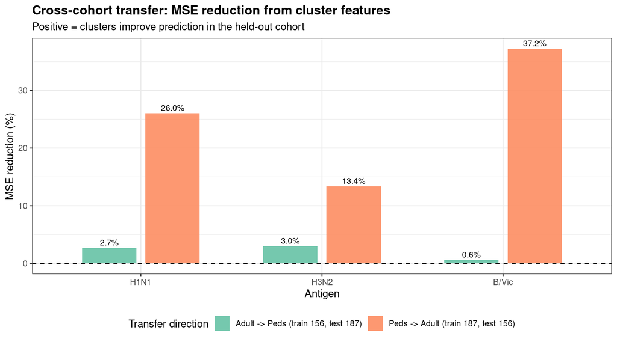

```r
if (file.exists(ATLAS_FILE)) {
  # The transfer diagnostic is precomputed and stored in the production atlas.
  atlas <- new.env(parent = emptyenv()); load(ATLAS_FILE, envir = atlas)
  transfer_dt <- as.data.table(atlas$transfer_dt)
} else {
  stop("Production atlas (with transfer_dt) not found; see Data Availability.")
}

transfer_dt[, direction_label := fifelse(direction == "peds_to_adult",
  sprintf("Peds -> Adult (train %d, test %d)", n_train, n_test),
  sprintf("Adult -> Peds (train %d, test %d)", n_train, n_test))]
transfer_dt[, virus_label := factor(virus, levels = c("h1n1", "h3n2", "bvic"),
                                    labels = c("H1N1", "H3N2", "B/Vic"))]
# Report as MSE reduction (positive = clusters help), i.e. minus the raw change.
transfer_dt[, mse_reduction := -improve_pct]

ggplot(transfer_dt, aes(virus_label, mse_reduction, fill = direction_label)) +
  geom_col(position = position_dodge(width = 0.7), width = 0.6, alpha = 0.9) +
  geom_hline(yintercept = 0, linetype = "dashed") +
  geom_text(aes(label = sprintf("%.1f%%", mse_reduction)),
            position = position_dodge(width = 0.7), vjust = -0.4, size = 3) +
  scale_fill_brewer(palette = "Set2", name = "Transfer direction") +
  labs(title = "Cross-cohort transfer: MSE reduction from cluster features",
       subtitle = "Positive = clusters improve prediction in the held-out cohort",
       x = "Antigen", y = "MSE reduction (%)") +
  theme_bw(base_size = 11) +
  theme(plot.title = element_text(face = "bold"), legend.position = "bottom")
```

```r
kable(transfer_dt[, .(Direction = direction, Antigen = toupper(virus),
                      `Baseline MSE` = round(baseline_mse, 3),
                      `Clusters MSE` = round(clusters_mse, 3),
                      `MSE reduction (%)` = round(mse_reduction, 1))],
      caption = "Cross-cohort transfer: cluster features vs baseline in the held-out cohort.")
```

Cross-cohort transfer: cluster features vs baseline in the held-out cohort.

| Direction | Antigen | Baseline MSE | Clusters MSE | MSE reduction (%) |
| --- | --- | --- | --- | --- |
| peds_to_adult | H1N1 | 5.449 | 4.030 | 26.0 |
| peds_to_adult | H3N2 | 4.189 | 3.629 | 13.4 |
| peds_to_adult | BVIC | 5.677 | 3.563 | 37.2 |
| adult_to_peds | H1N1 | 2.347 | 2.284 | 2.7 |
| adult_to_peds | H3N2 | 2.939 | 2.850 | 3.0 |
| adult_to_peds | BVIC | 2.655 | 2.640 | 0.6 |

A model trained on pediatric recipients transfers well to adults (13–37% MSE reduction across antigens), whereas the reverse direction gains only 1–3%. The asymmetry is consistent with the pediatric cohort spanning greater diversity in early immune reconstitution, which generalizes to the adult range.